# Split Sample Analysis

Author

Grace Bullied

```r
#packages needed for graphing
library(tidyverse)
```

```r
#packages needed to read data
library(googlesheets4)
```

# Introduction

This summer, our lab was introduced to the plankton splitter used to equally split a sample in half in order to identify the ideal 300-500 organisms instead of 1,000+ macroinvertebrates in full samples. The microhabitat UFR (upstream, fast, rocky) of the green sample taken on 6/5/23 was the first to be split into UFR-A and UFR-B using the plankton splitter. However, UFR-A looked noticeably larger than UFR-B, leading to the question, **how accurate is the sample split in terms of biodiversity and number of organisms?**

```r
#read data
UFRA <- read_sheet('https://docs.google.com/spreadsheets/d/13MoLbg5kr-mFca_SZFZ7gkKXPzbD6z-XN3jWmyI6cmI/edit#gid=0')
```

```
! Using an auto-discovered, cached token.
```

```
  To suppress this message, modify your code or options to clearly consent to
  the use of a cached token.
```

```
  See gargle's "Non-interactive auth" vignette for more details:
```

```
ℹ The googlesheets4 package is using a cached token for 'gbullied@smith.edu'.
```

```
✔ Reading from "UFR-A Split Sample Analysis".
```

```
✔ Range 'Sheet1'.
```

```r
UFRA
```

```
# A tibble: 25 × 3
   scientific_name life_stage number
   <chr>           <chr>       <dbl>
 1 Chironomidae    larva         353
 2 Pycnopsyche     larva           4
 3 Neophylax       larva           7
 4 Hydroptilidae   larva           1
 5 Psephenus       larva           3
 6 Stenelmis       larva           3
 7 Apatania        larva           1
 8 Stenacron       larva           4
 9 Stenonema       larva           1
10 Maccaffertium   larva           3
# ℹ 15 more rows
```

```r
UFRB <- read_sheet('https://docs.google.com/spreadsheets/d/1cCIpR0pO8veAa-3TEfsqMpwQKrQ3DANd142HPvIEEtE/edit#gid=0')
```

```
✔ Reading from "UFR-B Split Sample Analysis".
✔ Range 'Sheet1'.
```

```r
UFRB
```

```
# A tibble: 22 × 3
   scientific_name life_stage number
   <chr>           <chr>       <dbl>
 1 Chironomidae    larva         294
 2 Polycentropus   larva           1
 3 Pycnopsyche     larva           1
 4 Neophylax       larva           4
 5 Hydroptilidae   larva           1
 6 Psephenus       larva           5
 7 Stenelmis       larva           2
 8 Apatania        larva           1
 9 Stenacron       larva           4
10 Stenonema       larva           6
# ℹ 12 more rows
```

# Graphing

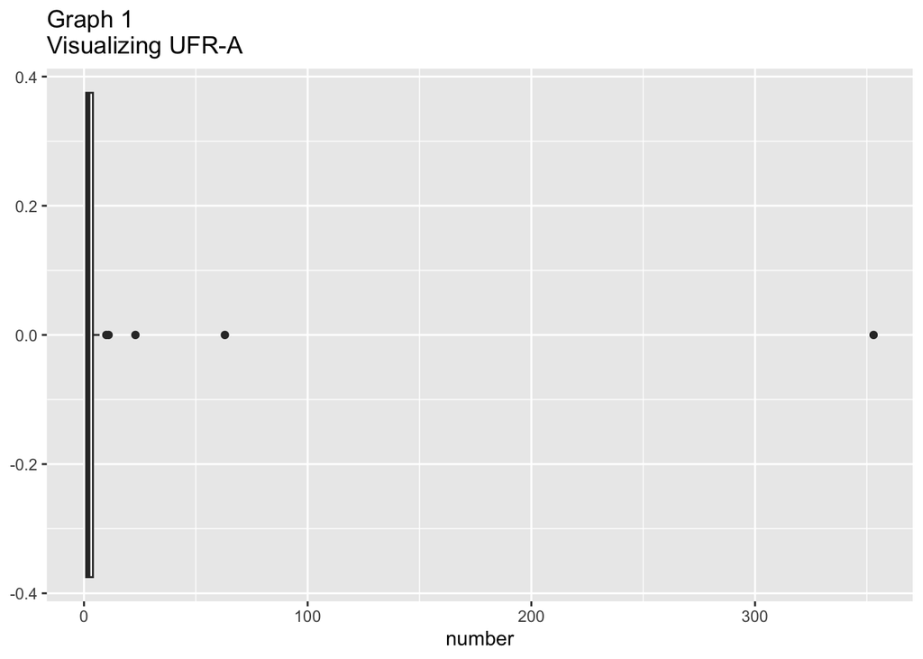

```r
ggplot(
  data = UFRA,
  mapping = aes(x = number)
) +
  geom_boxplot() +
  ggtitle("Graph 1 \nVisualizing UFR-A")
```

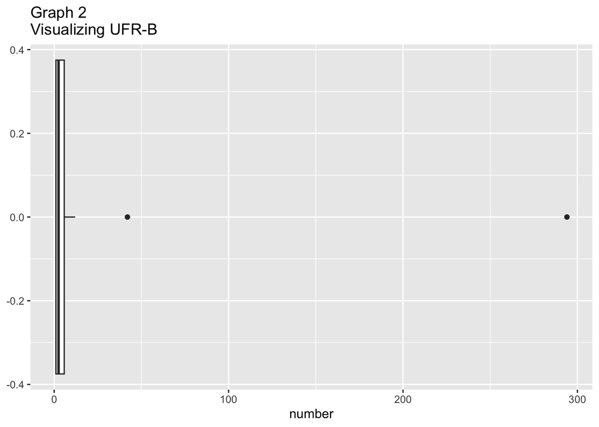

```r
ggplot(
  data = UFRB,
  mapping = aes(x = number)
) +
  geom_boxplot() +
  ggtitle("Graph 2 \nVisualizing UFR-B")
```

By graphing UFR-A and UFR-B in box plots, we are able to compare the interquartile range, middle 50% of the data, and visualize the outliers in order to assess variability. In UFR-A, Chironomidae larva totaled at 353 organisms, and Segmented_worms totaled at 63. In UFR-B, Chironomidae larva totaled at 294 organisms, and Segmented_worms totaled at 42. Due to these outliers, the data is very variable and will offer a less precise conclusion. Therefore, in order to best visualize the difference in biodiversity and total organisms in the split sample, we have to remove these values.

```r
#read edited data
UFRAedited <- read_sheet('https://docs.google.com/spreadsheets/d/1AScGvjQSn0eN5uLZHe4sHsTOn0nZ4BJHBokVu1KarIw/edit#gid=0')
```

```
✔ Reading from "UFR-A Edited".
```

```
✔ Range 'Sheet1'.
```

```r
UFRAedited
```

```
# A tibble: 23 × 3
   scientific_name life_stage number
   <chr>           <chr>       <dbl>
 1 Pycnopsyche     larva           4
 2 Neophylax       larva           7
 3 Hydroptilidae   larva           1
 4 Psephenus       larva           3
 5 Stenelmis       larva           3
 6 Apatania        larva           1
 7 Stenacron       larva           4
 8 Stenonema       larva           1
 9 Maccaffertium   larva           3
10 Leucrocuta      larva          23
# ℹ 13 more rows
```

```r
UFRBedited <- read_sheet('https://docs.google.com/spreadsheets/d/1PcxAI1jBSgzgOS9jpOgmibjiONzzxv3vM2Pwr2ZLM-0/edit#gid=0')
```

```
✔ Reading from "UFR-B Edited".
✔ Range 'Sheet1'.
```

```r
UFRBedited
```

```
# A tibble: 20 × 3
   scientific_name life_stage number
   <chr>           <chr>       <dbl>
 1 Polycentropus   larva           1
 2 Pycnopsyche     larva           1
 3 Neophylax       larva           4
 4 Hydroptilidae   larva           1
 5 Psephenus       larva           5
 6 Stenelmis       larva           2
 7 Apatania        larva           1
 8 Stenacron       larva           4
 9 Stenonema       larva           6
10 Maccaffertium   larva           3
11 Leucrocuta      larva          12
12 Procloeon       larva          10
13 Attenella       larva           3
14 Chironomidae    pupa            9
15 Agapetus        pupa            1
16 Antocha         pupa            1
17 Nematomorpha    adult           1
18 Ancylidae       adult           2
19 Caecidotea      adult           2
20 Trombidiformes  adult           1
```

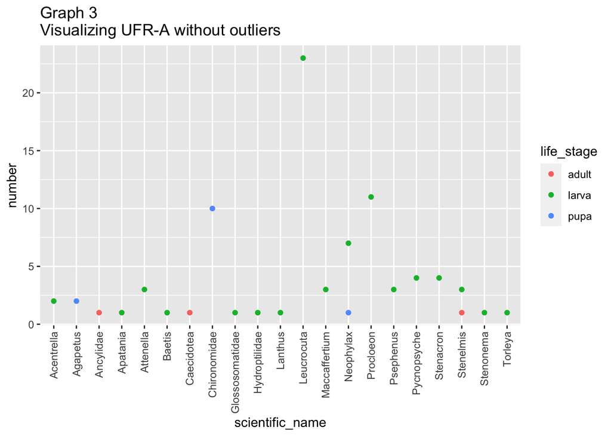

```r
ggplot(
  data = UFRAedited,
  mapping = aes(
    x = scientific_name,
    y = number,
    color = life_stage,
  )
) +
  geom_point() +
   theme(axis.text.x = element_text(angle = 90, vjust = 0.5, hjust=1)) +
  ggtitle("Graph 3 \nVisualizing UFR-A without outliers")
```

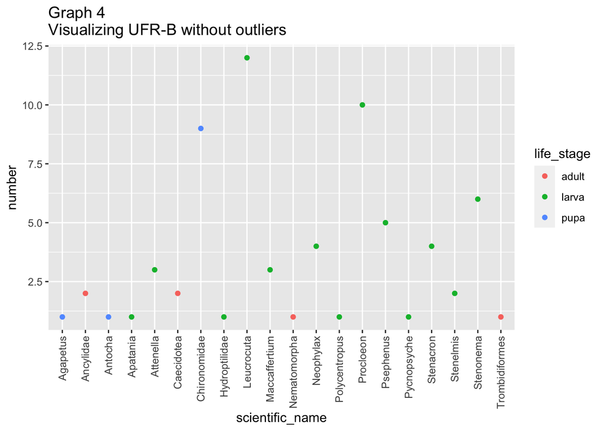

```r
ggplot(
  data = UFRBedited,
  mapping = aes(
    x = scientific_name,
    y = number,
    color = life_stage,
  )
) +
  geom_point() +
   theme(axis.text.x = element_text(angle = 90, vjust = 0.5, hjust=1)) +
  ggtitle("Graph 4 \nVisualizing UFR-B without outliers")
```

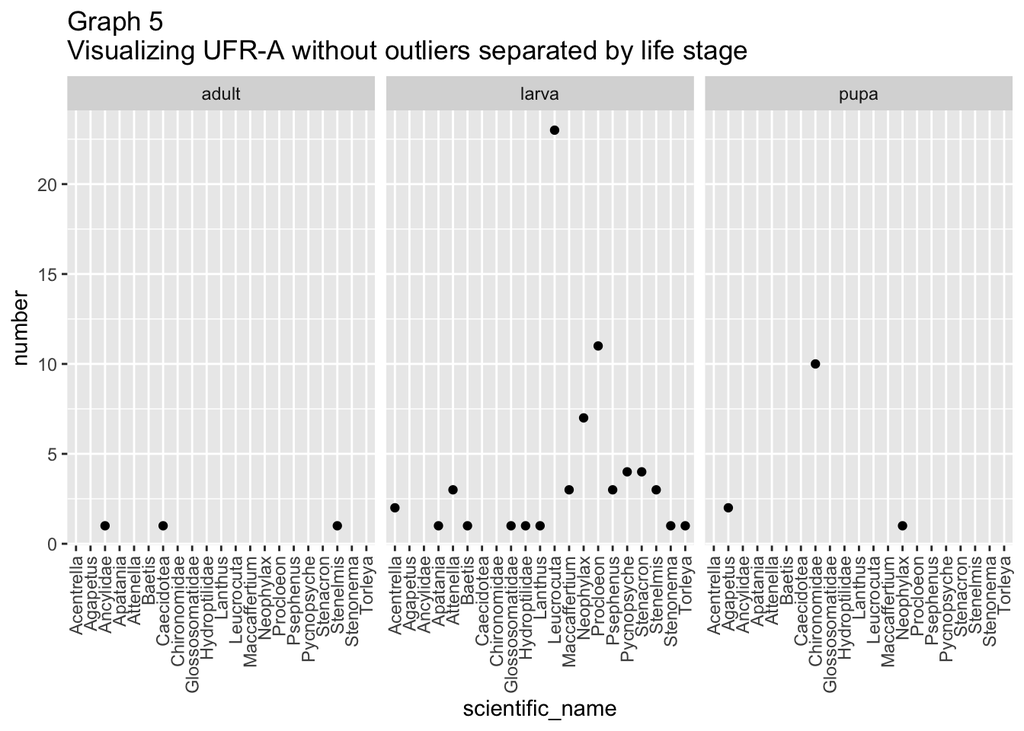

```r
ggplot(
  data = UFRAedited,
  mapping = aes(
    x = scientific_name,
    y = number,
  )
) +
  geom_point()+
  facet_wrap(vars(life_stage), ncol = 3) +
  theme(axis.text.x = element_text(angle = 90, vjust = 0.5, hjust=1)) +
  ggtitle("Graph 5 \nVisualizing UFR-A without outliers separated by life stage")
```

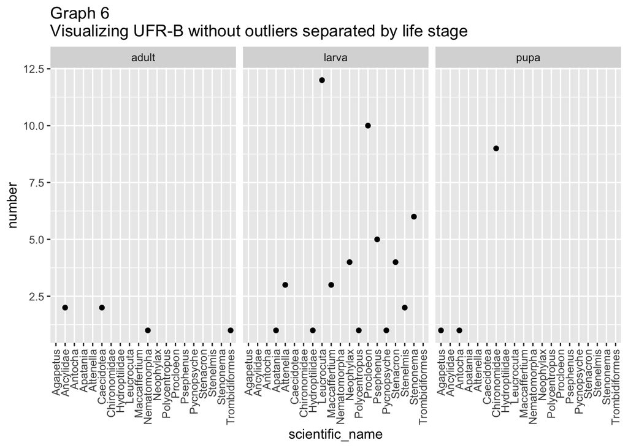

```r
#visualizing UFR-B without outliers separated by life stage
ggplot(
  data = UFRBedited,
  mapping = aes(
    x = scientific_name,
    y = number,
  )
) +
  geom_point()+
  facet_wrap(vars(life_stage), ncol = 3) +
  theme(axis.text.x = element_text(angle = 90, vjust = 0.5, hjust=1)) +
    ggtitle("Graph 6 \nVisualizing UFR-B without outliers separated by life stage")
```

# Analysis

###### Biodiversity

In terms of biodiversity, the graphs of UFR-A and UFR-B without outliers appear to have a similar biodiversity visualized by the spread of the variables. UFR-A is slightly more diverse at 21 genera compared to the 20 genera identified in UFR-B. In UFR-A, Acentrella, Torleya, Baetis, Glossosomatidae, and Lanthus genera were identified that were not found in URF-B. And similarly, in UFR-B, Polycentropus, Antocha, Nematomorpha, and Trombidiformes genera were identified that were not found in UFR-A.

###### Number of Organisms

In terms of the number of organisms, the graphs of UFR-A and UFR-B without outliers separated by life stage appear to have a similar values visualized by the shape of the graph. Majority of the identified genera in both UFR-A and UFR-B differ by 0-1 organisms. However, there are 5 genera that have a difference greater than 1, including Pycnopsyche, Neophylax, Psephenus, Stenonema, and Leucrocuta. Specifically, the difference in Leucrocuta identified in UFR-A is double than that identified in UFR-B, and is visibly skewing the shape. Similarly, but excluded from the graph, UFR-A has a higher number of both Chironomidae larva and Segmented Worms than UFR-B. Including these families, UFR-A has a total of 502 organisms and UFR-B has a total of 406 organisms.

# Conclusion

###### Possible Errors

As previously noted, UFR is the first sample to be split using the plankton splitter, and could have experienced challenges with the new equipment or new user. To more accurately assess the plankton splitter, we can split more samples and similarly identify and compare the organisms in both halves.